# Project 2

Kaleb Luna

2024-11-13

# The Human Development Index (HDI): How does it compare across the world?

# Introduction

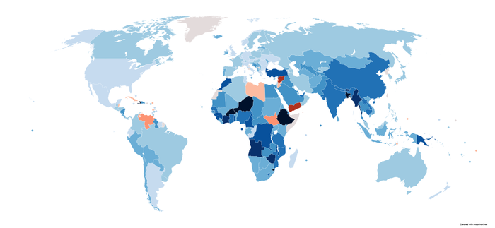

*Image Cited: Wikipedia contributors. (2003, July 5). Human Development Index - Wikipedia. https://en.wikipedia.org/wiki/Human_Development_Index*

The data set of interest contains measures related to the Human Development Index (HDI), a statistic established by the United Nations to assess a nation’s overall level of human development based on three factors: health, knowledge and standard of living. These three primary factors are assessed by:

- Mean and Expected years of schooling
- Life Expectancy at Birth
- Gross National Income (GNI) per capita

I have chose this dataset because it allows making real insights into key human development indicators, including HDI, life expectancy, education, and more-things that are quite relevant in trying to understand disparities across the world. More specifically, I was interested in examining how such factors as income and education interact in influencing certain development outcomes across countries. In this data set, I felt that I would be able to gain an opportunity to test these relationships and further understand the challenges and opportunities for improvement in global well-being.

# Data Preparation

To obtain the dataset, I accessed the United Nations Human Development Reports Data Center, specifically at the HDI Information page at [https://hdr.undp.org/data-center/human-development](https://hdr.undp.org/data-center/human-development-index#/indicies/HDI) index#/indicies/HDI. I downloaded the data set in an Excel XLSX format, then converting it to a .csv format by importing the dataset into Google Sheets. From there, I was able to obtain the provided indicators of interest such as **HDI, mean and expected years of schooling, life expectancy, GNI per capita, and HDI rank** for each country.

After importing the data set into R using the read.csv(), I performed the following steps to clean up the data set:

- I removed all unnecessary columns and rows, mainly elements that were used to separate the data in the initial format that would’ve interfered with the import of the data set into R. Furthermore, there were a few blank cells in the data set for countries that have provided no data in certain columns (e.g. North Korea); therefore, I replaced these blank cells with NAs.
- I ensured the each of the variables of interests were of the correct data types. For example, I ensured that HDI rank and years of schooling were set to numeric values, while country names were set as string/factors.

Throughout the process, the challenges I came across mainly revolved around data points that were not available and incomplete data as indicated by the NA values, specifically in countries such as North Korea.

Variable Descriptions for HDI Dataset

| Variable | Type | Description |
| --- | --- | --- |
| Country | String | Name of the country. |
| Human.Develoopment.Index..HDI. | Numeric | Human Development Index (HDI) score for the country, a composite measure of overall human development. |
| Life.expectancy.at.birth | Numeric | Average life expectancy at birth, indicating the health status of the population. |
| Mean.years.of.schooling | Numeric | Average years of schooling received by people ages 25 and older, reflecting educational attainment. |
| Expected.years.of.schooling | Numeric | Expected years of schooling for children of school-entry age, indicating potential educational outcomes. |
| Gross.national.income..GNI..per.capita | Numeric | Gross National Income per capita (in USD), showing the economic prosperity of the country. |

# Univariate Analysis

## HDI Index

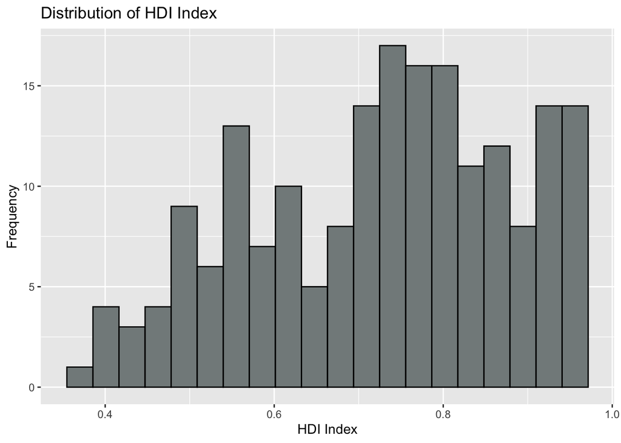

The distribution of the HDI index is slightly skewed to the left, with a mean of 0.73 and a standard deviation of 0.15.

## Life Expectancy

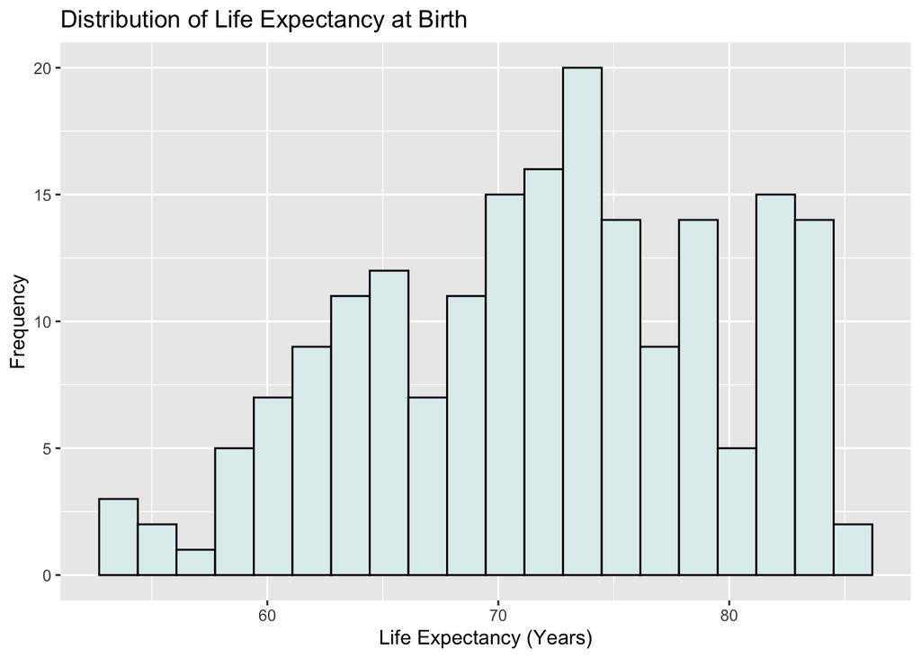

The distribution of the Life Expectancy at Birth is slightly skewed to the left, with a mean of 71.93 years and a standard deviation of 7.80 years.

## Mean Years of Schooling

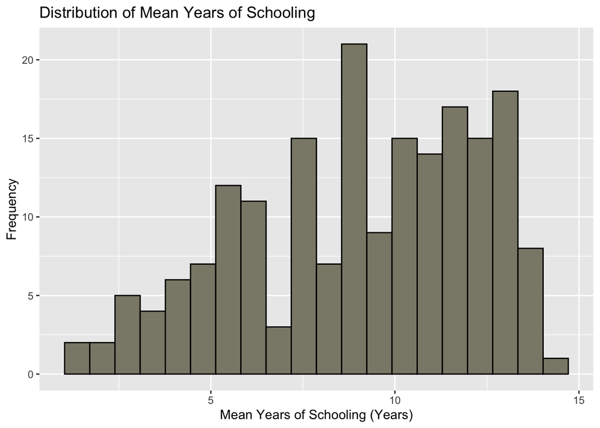

The distribution of the Mean Years of Schooling is slightly skewed to the left, with a mean of 9.05 years and a standard deviation of 3.19 years.

#### Comparing the Gap between Mean Years of Schooling vs. Expected Years of Schooling Across Countries

Schooling Gap Across Countries

| Country | Schooling Gap |
| --- | --- |
| Switzerland | 2.7 |
| Norway | 5.5 |
| Iceland | 5.3 |
| Hong Kong, China (SAR) | 5.5 |
| Denmark | 5.8 |
| Sweden | 6.3 |
| Germany | 3.0 |
| Ireland | 7.4 |
| Singapore | 5.0 |
| Australia | 8.4 |
| Netherlands | 6.0 |
| Belgium | 6.4 |
| Finland | 6.3 |
| Liechtenstein | 3.1 |
| United Kingdom | 4.2 |
| New Zealand | 6.8 |
| United Arab Emirates | 4.4 |
| Canada | 2.1 |
| Korea (Republic of) | 3.9 |
| Luxembourg | 1.2 |
| United States | 2.8 |
| Austria | 4.1 |
| Slovenia | 4.5 |
| Japan | 2.8 |
| Israel | 1.6 |
| Malta | 3.7 |
| Spain | 7.2 |
| France | 4.3 |
| Cyprus | 3.8 |
| Italy | 6.0 |

[output cut: 162 more lines]

## Gross National Income per Capita

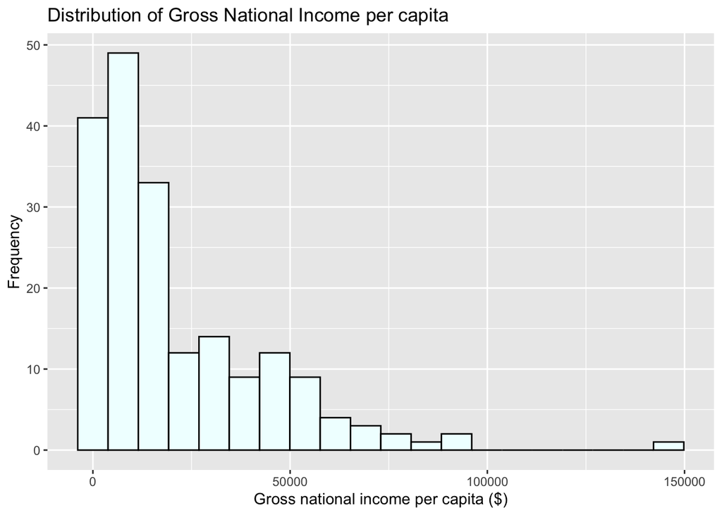

The distribution of the Gross National Income per capita is skewed to the right, with a mean of $21,161 and a standard deviation of $22,543.09.

#### Addressing the Distribution of Income Categories across Countries

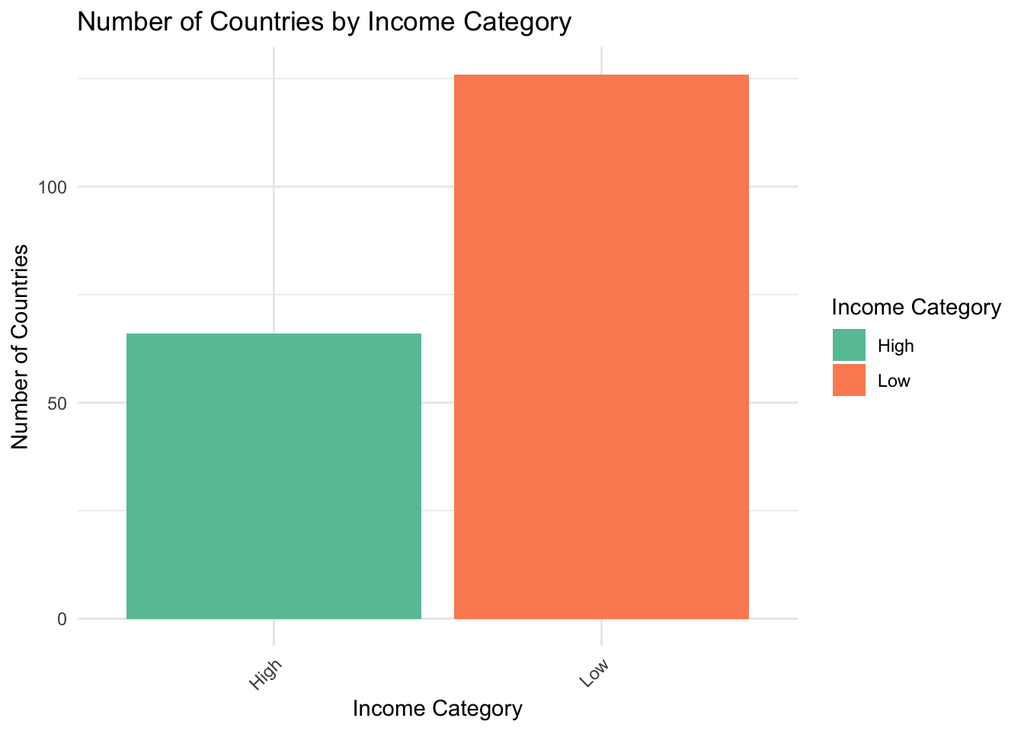

# Bivariate Analysis

## HDI by Country (Top 20)

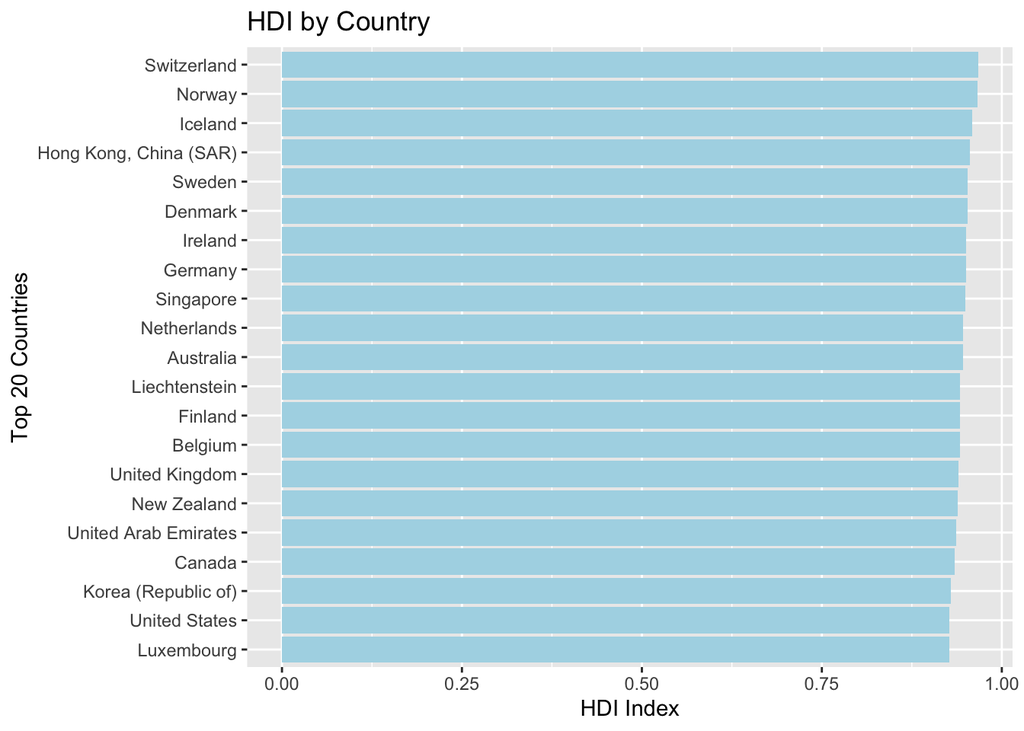

The mean HDI index is 0.7255312. The country with the highest life expectancy is Japan at 84.8 years.

## Mean Years of Schooling vs. Life Expectancy at Birth

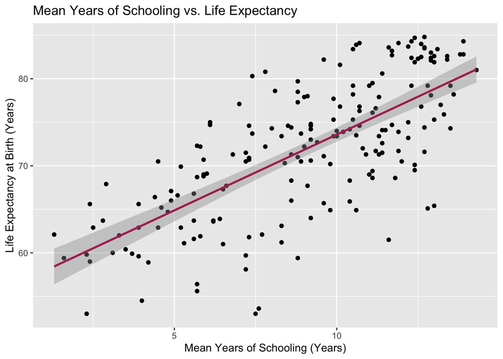

```
## [1] 0.7119008
```

With a correlation coefficient of 0.71, the scatter plot suggests a strong, positive relationship between the **mean years of schooling and life expectancy at birth**. This reveals that higher education levels tend to correlate with better health and prosperity.

## Mean Years of Schooling vs. GNI per Capita

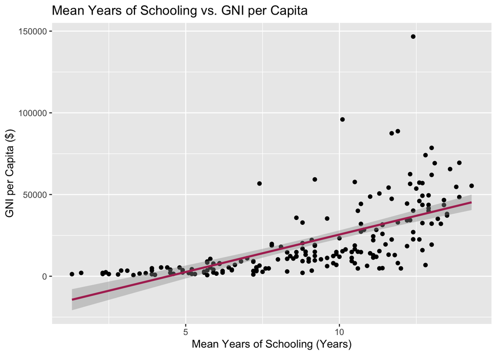

```
## [1] 0.6484194
```

With a correlation coefficient of 0.65, the graph depicting the relationship between **Mean Years of Schooling vs. GNI per capita** suggests a moderate to strong positive correlation between the two variables, meaning that countries with a higher educational opportunity tend to have a higher GNI per capita.

## HDI vs. Life Expectancy at Birth

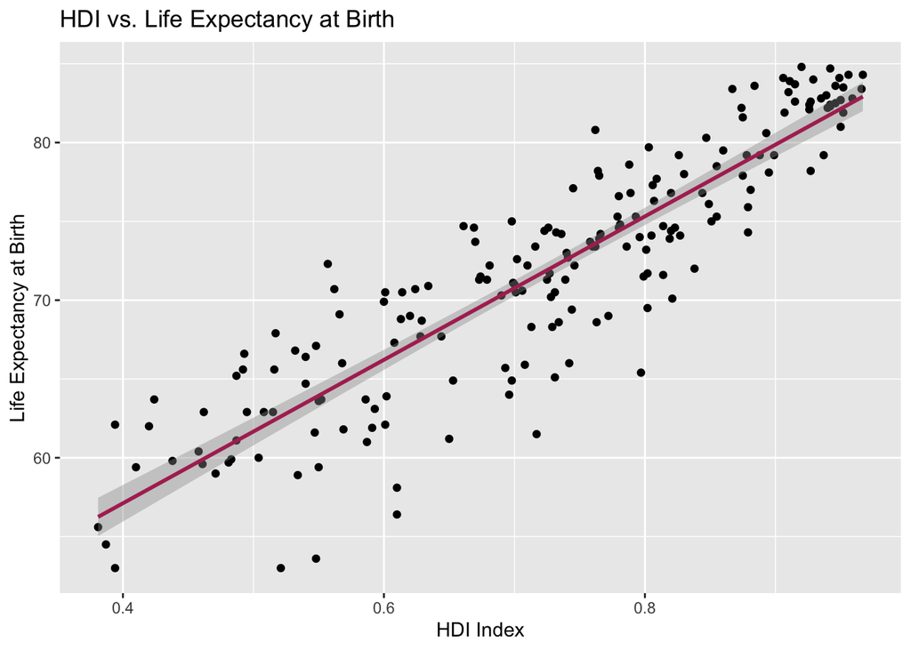

```
## [1] 0.8960847
```

With a correlation coefficient of 0.90, the graph depicting the relationship between **HDI vs. Life Expectancy at Birth** reveals a strong, positive correlation between the two variables, which suggest that countries with a higher HDI tend to have longer life expectancies.

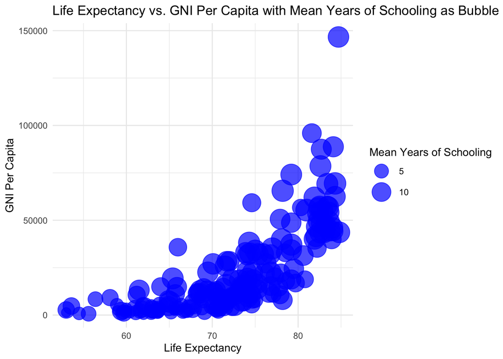

The plot above shows how l**ife expectancy and GNI per capita** are related across the countries in the dataset, with the size depicting **the mean years of schooling**. With this, we can interpret that countries with a higher GNI tend have higher life expectancies. Furthermore, larger bubbles are generally associated higher GNI per capita and life expectancy.

# Choice Elements

# Conclusion

Overall, the findings of this project did match what I expected as I came into this topic knowing prior knowledge about how development is influenced by such factors (education, health, economic prosperity).

# Reproducibility

https://github.com/kalebjoel/Project-2

- Clone the repository and install necessary R packages, including `dplyr`, `ggplot2`, `tidyr`, `readr`, and `knitr`.
- Download the dataset from the UNDP Human Development Index website or use the dataset file included in the repository (e.g., `Human Development Index Data -HDI.csv`).
- Load the dataset into R, clean it by handling missing values, creating new variables (e.g., schooling gap), and reshaping data for analysis.
- Execute the provided R Markdown file (`Project2.Rmd`) to run the analysis, generate visualizations, and produce the final knitted report.

# References

- United Nations. (n.d.). *Human Development Index*. Human Development Reports. https://hdr.undp.org/data-center/human-development-index#/indicies/HDI
- Team, I. (2024, June 21). *What is the Human Development Index (HDI)?* Investopedia. https://www.investopedia.com/terms/h/human-development-index-hdi.asp
- United Nations. (2024, November 13). *DESA-EN | United Nations*. https://www.un.org/en/desa